# Microarray Analysis PAC1

David Cartoixà Cartoixà

April 18,2020

**INDICE DE CONTENIDOS**

1.Abstract 2.Objetivo del estudio y datos 2.1.Objetivos del estudio 2.2.Obtención de las muestras 2.3. Análisis de microarrays 3.Métodos 3.1.Preparación del entorno de trabajo 3.2.Preparación de los datos para el análisis 3.3.Instalación de paquetes en R 3.4.Lectura de los archivos .CEL 3.5.Control de calidad de los datos sin procesar 3.6.Control de calidad de los datos procesados 3.7.Análisis de batch 3.8.Detección de los genes más variables 3.9.Filtrado de genes 3.10.Guardado de los datos normalizados y filtrados 3.11.Definición de la matriz de diseño 3.12.Definición de la matriz de contrastes 3.13.Estimación del modelo y selección de genes 3.14.Obtención de una lista de genes expresados diferencialmente 3.15.Anotación genética 3.16.Visualización de la expresión diferencial 3.17.Comparaciones múltiples 3.18.Heatmaps 3.19.Significación biológica de los resultados 4.Código R 5.Referencias

El siguiente informe y sus datos se pueden consultar en https://github.com/dcc1978/Statistical-Analysis-of-Microarray-Data-PEC1/

# 1.Abstract

El factor de crecimiento transformante $\beta1$ ($TGF\beta1$) es una citocina implicada en el control y la diferenciación celular, la desregulación de la activación y de la ruta de señalización de ($TGF\beta1$) puede desencadednar apoptosis.Se ha demostrado que la CAV1 o caveolina-1, que es una proteina transmembrana, altera la señalización de ($TGF\beta1$).En el estudio se utilizaron hepatocitos estimulados con el factor de crecimiento en ratones normales y en ratones knock-out para caveolina.

# Palabras clave

Caveolina-1, factor de crecimiento transformante $\beta1$, metabolismo, enfermedades hepáticas, microarray

# 2.Objetivos del estudio y datos

## 2.1.Objetivos del estudio

El objetivo del estudio es evaluar si el papel de la caveolina-1 sobre afecta el control de los gene signature inducidos por el factor de crecimiento transformante $\beta1$, en consecuencia se pretende un mejor conocimiento de la función de ($TGF\beta1$) en hígado sano y en hígado enfermo, donde los niveles de CAV1 se encuentran implicados.

## 2.2. Obtención de las muestras

- Se utilizaron cuatro grupos de hepatocitos de ratón C57BL/6 de doce semanas de edad:
  - Grupo 1: cultivado con CAV1 y con $TGF\beta1$.
  - Grupo 2: cultivado con CAv1.
  - Grupo 3: cultivado con $TGF\beta1$.
  - Grupo 4: grupo control.

## 2.3 Análisis de microarrays

# 3. Métodos

## 3.1 Preparación del entorno de trabajo

Primeramente definiremos el directorio de trabajo, y crearemos tres carpetas: “data” donde almacenaremos los archivos .CEL descomprimidos y los archivos generados por nosotros target; una carpeta “results” donde registraremos los resultados obtenidos y finalmente la carpeta “figures” en la cual almacenaremos las figuras del estudio.

```r
> setwd(".")
> dir.create("data")
> dir.create("results")
> dir.create("figures")
```

## 3.2 Preparación de los datos para el análisis

Los datos para el análisis constan de dos tipos de archivo, los archivos “CEL”(en nuestro caso 12 archivos .CEL que hemos descargado), y un archivo “targets.xlsx” que posteriormente convertimos a “targets.csv”. Los archivos “CEL” son los datos sin procesar originados después de escanear y preprocesar el microarray con el software Affymetrix. Los archivos mencionados los almacenaremos en la carpeta “data”. El archivo “targets” contiene la información sobre grupos y covariables, relaciona el nombre de cada archivo .CEL con su condición en el experimento.

Para el análisis el archivo targets ha sido guardado con formato .csv, hemos creado el archivo a raíz de la información obtenida en (https://www.ncbi.nlm.nih.gov/geo/query/acc.cgi?acc=GSE137339). La tabla 1 muestra el contenido del archivo “targets” utilizado en el presente análisis:

Tabla1. Contenido del fichero targets utilizados para el análisis

| Accession | Title | Sirma | Treatment | ShortName | Group |
| --- | --- | --- | --- | --- | --- |
| GSM4075756 | siCav1+TGF-Beta1 rep1 | Caveolin-1 | TGFBeta | Cav1.TGFB1 | Cav.TGFB1 |
| GSM4075757 | siCav1+TGF-Beta1 rep2 | Caveolin-1 | TGFBeta | Cav1.TGFB2 | Cav.TGFB1 |
| GSM4075758 | siCav1+TGF-Beta1 rep3 | Caveolin-1 | TGFBeta | Cav1.TGFB3 | Cav.TGFB1 |
| GSM4075759 | siCAV1 rep1 | Caveolin-1 | Ctrl | Cav1.Ctrl1 | Cav.Ctrl |
| GSM4075760 | siCAV1 rep 2 | Caveolin-1 | Ctrl | Cav1.Ctrl2 | Cav.Ctrl |
| GSM4075761 | siCAV1 rep 3 | Caveolin-1 | Ctrl | Cav1.Ctrl3 | Cav.Ctrl |
| GSM4075762 | siCon+TGF-Beta1 rep 1 | Ctrl | TGFBeta | Con1.TGFB1 | Con.TGFB1 |
| GSM4075763 | siCon+TGF-Beta1 rep 2 | Ctrl | TGFBeta | Con1.TGFB2 | Con.TGFB1 |
| GSM4075764 | siCon+TGF-Beta1 rep 3 | Ctrl | TGFBeta | Con1.TGFB3 | Con.TGFB1 |
| GSM4075765 | siCon rep 1 | Ctrl | Ctrl | Con1.Ctrl1 | Con.Ctrl |
| GSM4075766 | siCon rep 2 | Ctrl | Ctrl | Con1.Ctrl2 | Con.Ctrl |
| GSM4075767 | siCon rep 3 | Ctrl | Ctrl | Con1.Ctrl3 | Con.Ctrl |

## 3.4. Lectura de los archivos CEL

El siguiente paso es leer los datos sin procesar (archivos .CEL) y almacenar los datos en una variable (en este caso lo hemos llamado rawData). Primero tenemos que cargar el paquete oligo con la biblioteca de funciones. En este paquete se codifican las funciones para leer los archivos CEL.

```
Reading in : ./data/GSM4075756_Meyer_270213_6-sicav_+48h_TGFbeta-I_MoGene-1_0-st-v1_.CEL
Reading in : ./data/GSM4075757_Meyer_270213_12-sicav_+48h_TGFbeta-III_MoGene-1_0-st-v1_.CEL
Reading in : ./data/GSM4075758_Meyer_270213_18-sicav_+48h_TGFbeta-IV_MoGene-1_0-st-v1_.CEL
Reading in : ./data/GSM4075759_Meyer_270213_4-sicav_48h-I_MoGene-1_0-st-v1_.CEL
Reading in : ./data/GSM4075760_Meyer_270213_10-sicav_48h-III_MoGene-1_0-st-v1_.CEL
Reading in : ./data/GSM4075761_Meyer_270213_16-sicav_48h-IV_MoGene-1_0-st-v1_.CEL
Reading in : ./data/GSM4075762_Meyer_270213_5-sico_+48h_TGFbeta-I_MoGene-1_0-st-v1_2.CEL
Reading in : ./data/GSM4075763_Meyer_270213_11-sico_+48h_TGFbeta-III_MoGene-1_0-st-v1_.CEL
Reading in : ./data/GSM4075764_Meyer_270213_17-sico_+48h_TGFbeta-IV_MoGene-1_0-st-v1_.CEL
Reading in : ./data/GSM4075765_Meyer_270213_3-sico_48h-I_MoGene-1_0-st-v1_.CEL
Reading in : ./data/GSM4075766_Meyer_270213_9-sico_48h-III_MoGene-1_0-st-v1_.CEL
Reading in : ./data/GSM4075767_Meyer_270213_15-sico_48h-IV_MoGene-1_0-st-v1_.CEL
```

Para facilitar nuestro trabajo, cambiaremos el nombre largo por las abreviaturas asignadas (ShortName):

```r
> colnames(rawData) <-rownames(pData(rawData)) <- my.targets@data$ShortName
```

## 3.5.Control de calidad de los datos sin procesar

Empleamos la libreria “arrayQualityMetrics()” para realizar el control de calidad de los raw data. Comprobamos los resultados del análisis de calidad en una carpeta QCDIR.raw creada dntro de la carpeta de resultado creada anteriormente. Dentro de ésta carpeta buscaremos un archivo llamado index.html, que abre una página web desde donde podremos acceder a un resumen del análisis realizado. La figura 1 muestra el encabezado de éste archivo que contiene una tabla con tres columnas que indican algunos criterios de calidad que deben ser verificados. Se han marcado 5 muestras, generlamente si sólo hay una marca significa que los problemas potenciales que pueden acarrear son pequeños, por lo que podemos decidir mantener todas las muestras en el análisis.

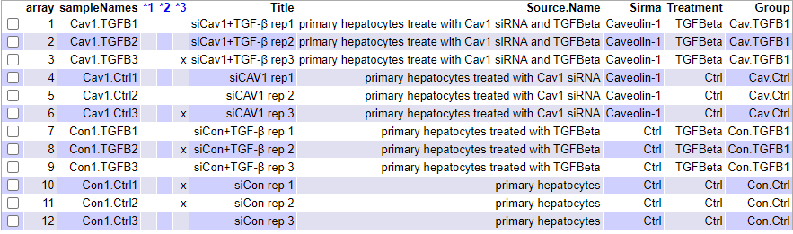

Figura1. Resumen del control de calidad de los datos crudos producido por arrayQualityMetrics()

```r
> require(arrayQualityMetrics)
> arrayQualityMetrics(rawData, outdir = file.path("./results", "QCDir.Raw"), force=TRUE)
```

Realizaremos otro análisis de calidad, el análisis de componentes principales (PCA Analysis) y generando su gráfica, la cual podemos apreciar en la figura 2.

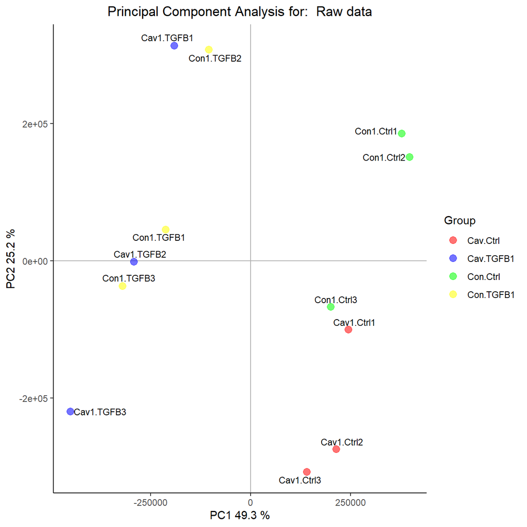

Figura 2.Visualización de los componentes principales de los datos sin procesar

El primer componente del PCA abarca un total del 49.3% de la variabilidad de las muestras,y el segundo abarca un 25.2%. Podemos deducir que la variabilidad está condicionada al tipo de tratamiento, ya que en el análisis se observa claramente como los grupos se diferencian al estar tratados con el factor de crecimiento o sin él.

Realizamos una figura de la distribuión de las intensidades mediante un “boxplot”en la figura 3, donde observamos una ligera variación de las intensidades entre arrays, pero es lo esperado para los datos sin procesar. Cada color representa a un grupo de datos.

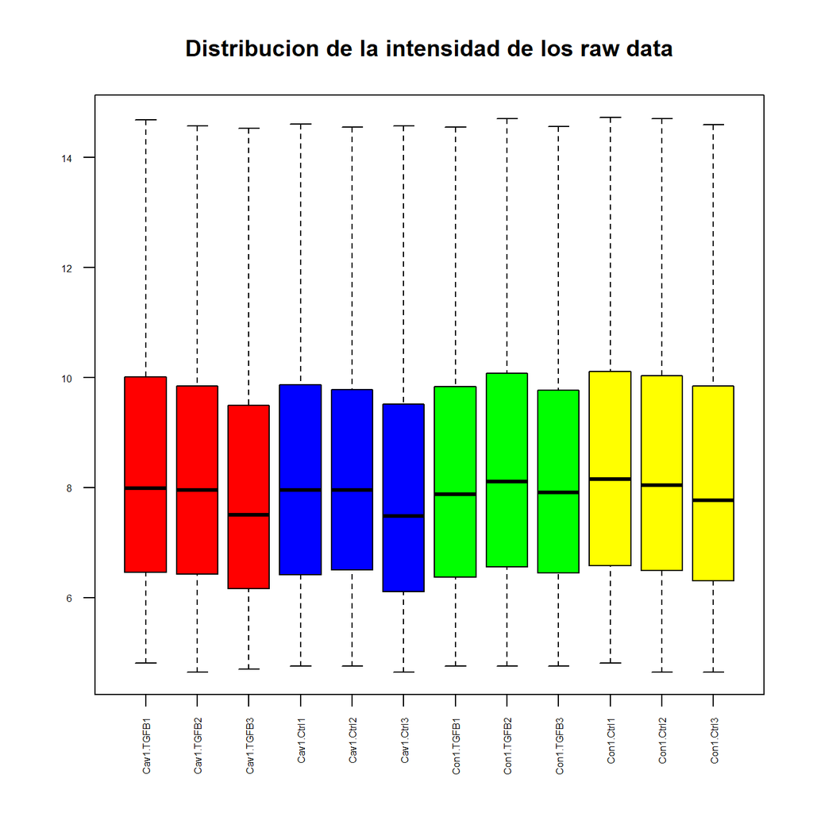

Figura 3.Boxplot de los datos sin procesar

## 3.6. Control de calidad de los datos procesados

Antes de emprender el análisis de la expresión diferencial, necesitamos optimizar los arrays y que sean comparables entre ellos, reduciendo y si es posible eliminando, toda la variabilidad de las muestras que no son debidas a razones biológicas. Queremos pues, asegurarnos que las diferencias son debidas a la expresión diferencial de los genes y no a sesgos artificiales debidos a problemas técnicos.

Volvemos a realizar un control de los datos normalizados para compararlos con los rawdata

```r
> library(arrayQualityMetrics)
> arrayQualityMetrics(eset_rma,outdir=file.path("./results/QCDir.Norm"),force=TRUE)
```

Los resultados obtenidos de arrayQualityMetrics nos muestrasn una notable mejora de los indicadores

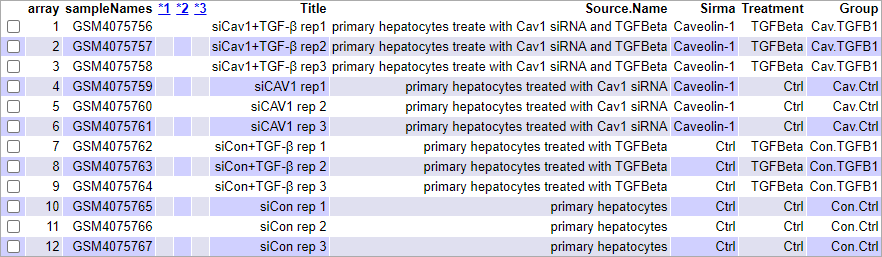

Figura4. Resumen de resultados del control de calidad para de los datos normalizados

La figura 4 muestra el mismo resumen que el mostrado anteriormente, pero se realiza con datos normalizados. Obsérvese que ya no hay ninguna columna marcada.

Realizamos un gráfico del análisis de los componentes principales realizados en datos normalizados:

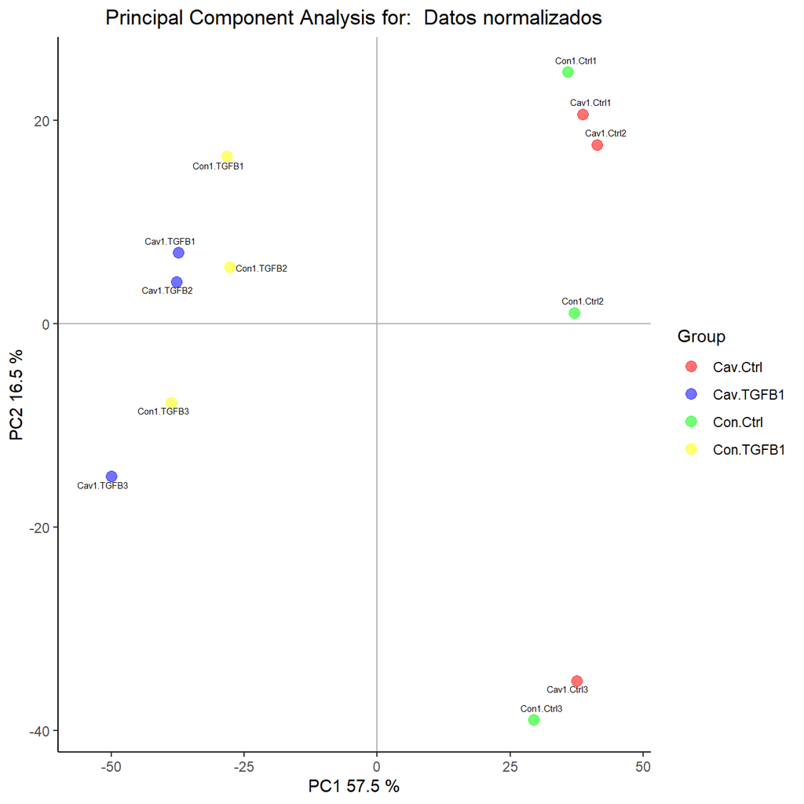

Figura 5.Visualización de los componentes principales de los datos normalizados

En la figura 5 vemos que el primer componente representa el 57.5% de la variabilidad total, el porcentaje de variabilidad explicada ha aumentado con respecto al análisis anterior en datos sin procesar. Del mismo modo que con el PCA con datos sin procesar, separa las muestra de la condición sin TGFB1 a la derecha y las muestras tratadas con TGFB1 a la izquierda.

Volvemos a diseñar un boxplot pero esta vez con los datos normalizados para contrastarlos con el boxplot anterior.

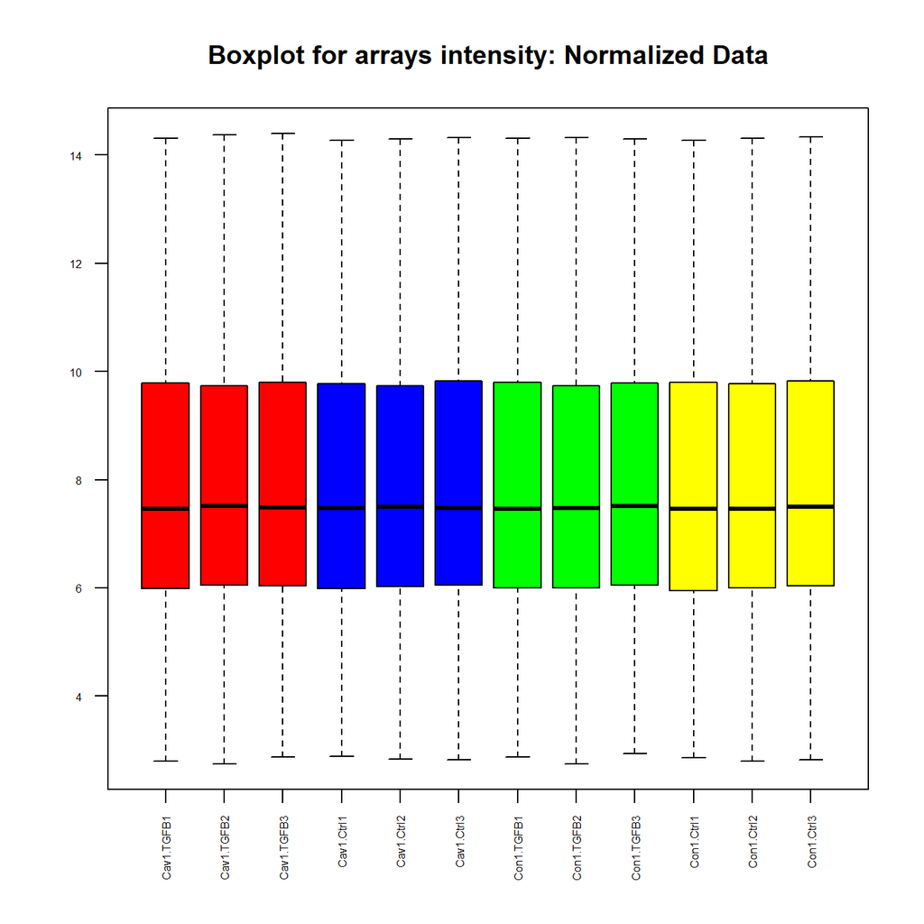

Figura 6. Boxplot de los datos normalizados

En la figura 6 se observa una gráfica boxplot que representa la distribución de las intensidades normalizadas a lo largo de todas las muestras con los datos normalizados, sugiere que la normalización ha funcionado correctamente.

Como una siguiente observación al análisis de normalización, haremos una comparativa de los gráficos “MA-plot”, haciendo una comparativa de los gráficos que corresponden a las muestras sin procesar (figura 7) y a las muestras normalizadas (figura 8). Observamos que los datos se centran a lo largo del eje M=0, que es lo que esperabamos.

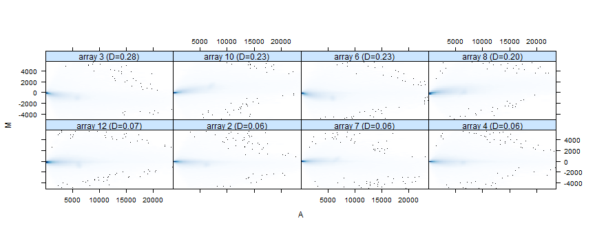

Figura 7.MA plot de los datos sin procesar

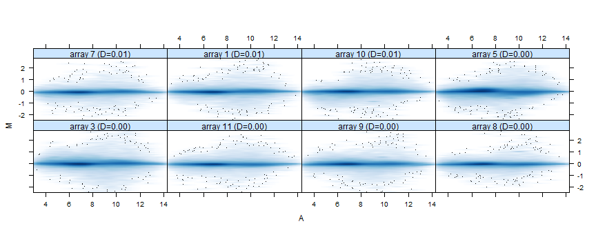

Figura 8.MA plot de los datos normalizados

## 3.7. Análisis de batch

Los resultados de los microarrays de expresión génica pueden verse afectados por diferencias minúsculas en cualquier número de variables no biológicas como reactivos de diferentes lotes, la manipulación de técnicos diferentes y la más habitual que es la diferente fecha de procesamiento de las muestras del mismo experimento. El error acumulativo introducido por éstas variaciones experimentales se conoce como “efectos por lotes” o “batch effect”. Se han desarrolado diferentes enfoques para identificar y eliminar los efectos por lostes de los datos de microarrays,utilizaremos el análisis PVCA (análisis de variación principal):

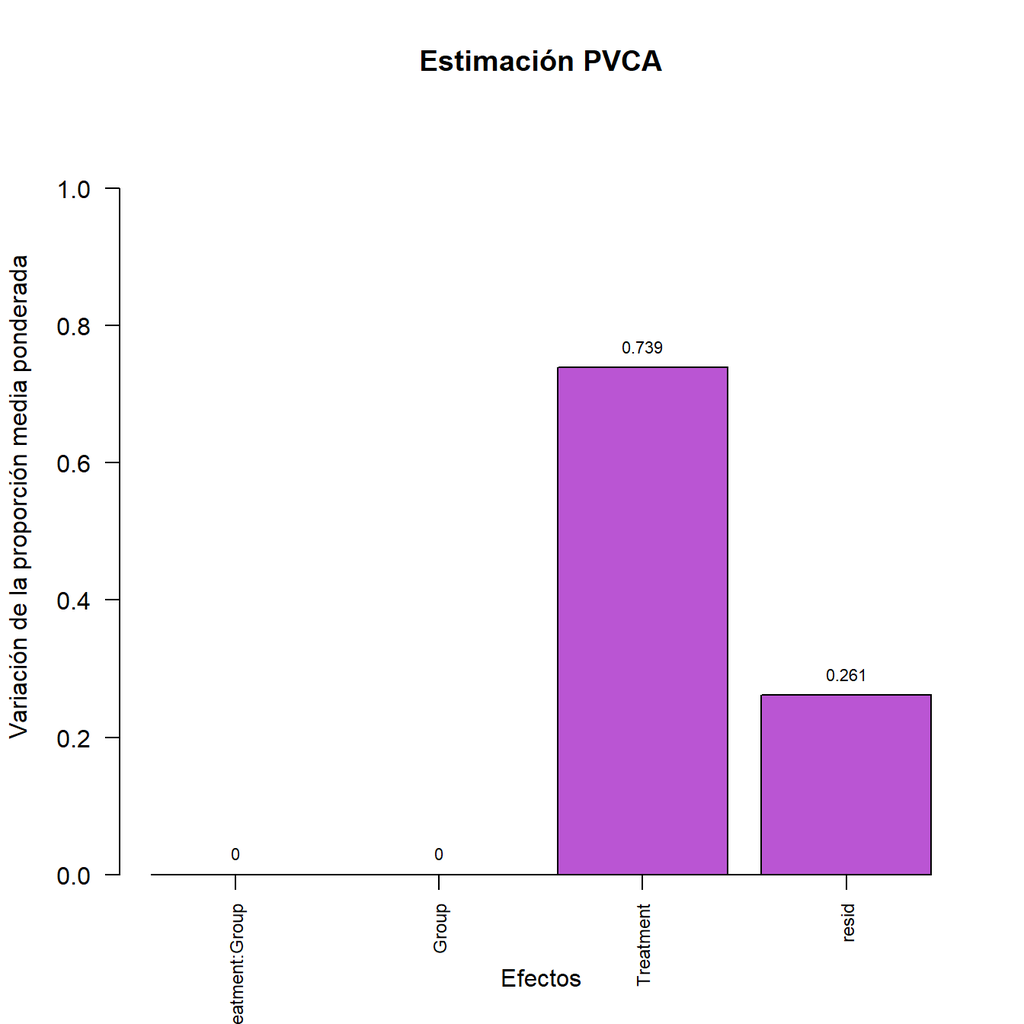

Figura 9.Estimación PVCA

Los resultados de la figura 9 muestran que la principal variación es debida al tratamiento al cual están sometidas las muestras, es un factor experimental incorporado en el análisis, por lo tanto se espera que suponga una variación significativa. Podemos descartar pues fuentes de variación debidas a aspectos metodológicos del experimento.

## 3.8. Detección de los genes más variables

La selección diferencial de genes expresados se ve afectada por el número de genes a analizar. Cuanto mayor sea el número mayor será el ajuste necesario de los p valores. Si un gen se expresa diferencialmente, se espera que haya una cierta diferencia entre grupos, por lo tanto la varianza global del gen será mayor que la de aquellos que no tienen expresión diferencial. Trazar la variabilidad general de todos los genes es útil para decidir qué porcentaje de genes muestran una variabilidad que puede atribuirse a otras causas que no sean la variabilidad aleatoria. En la figura 10 se representan las desviaciones estándar de todos los genes ordenados de más pequeño a más grande, la gráfica muestra que los genes más variables son aquellos con una desviación estándar por encima del 90-95%:

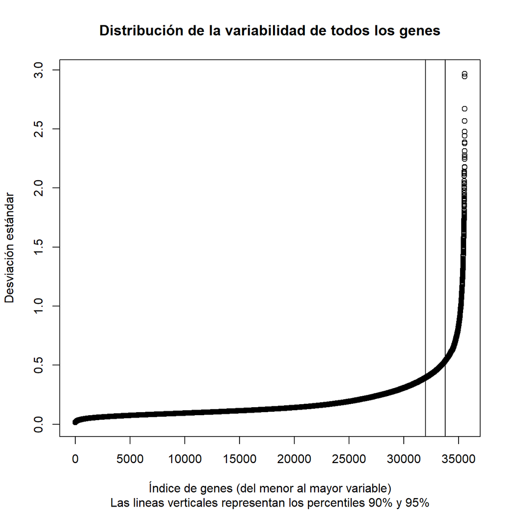

Figura 10. Valores de las desviaciones estándar de las muestras de los genes ordenados de menor a mayor

## 3.9. Filtrado de genes

Pretendemos filtrar aquellos genes cuya variabilidad puede atribuirse a una variación aleatoria, es decir, aquellos genes que, razonablemente no se espera que se expresen diferencialmente. La función nsFilter del paquete bioconductor se puede utilizar para eliminar genes basados en un umbral de variabilidad. Mostramos la cantidad de genes que han sido filtrados:

```
$numDupsRemoved
[1] 1781

$numLowVar
[1] 15226

$numRemoved.ENTREZID
[1] 13474
```

## 3.10. Guardado de los datos normalizados y filtrados

```r
> write.csv(exprs(eset_rma), file="./results/normalized.Data.csv")
> write.csv(exprs(eset_filtered), file="./results/normalized.Filtered.Data.csv")
> save(eset_rma, eset_filtered, file="./results/normalized.Data.Rda")
```

La función nsFilter devuelve los valores filtrados y un informe de los resultados del filtrado. Los datos filtrados son el punto de partida para análisis posteriores, pero es posible que deseemos volver a ellos, por ejemplo para revisar valores específicos de expresión génica.

## 3.11. Definición de la matriz de diseño

La selección de genes diferenciales expresados consiste en hacer alguna prueba, generalmente de carácter genético para comprobar la expresión entre grupos. El protocolo que utilizaremos será el método de los modelos lineales para microarrays, implementado en el paquete de limma para seleccionar genes expresados de forma diferencial.

El primer paso para el análisis basado en modelos lineales es crear la matriz de diseño, básicamente es una matriz que descirbe la asignación de cada muestra a un grupo o condición experimenta. Tiene tantas filas cmo muestras y tantas columnas como grupos. La matriz de diseño se puede definir de manera manueal oa a aprtir de una variable de factor que puede haber sido introducida en el archivo “targets”. En nuestro estudio, la variable “Grupo” es una combinación de las condiciones experimentales “Caveolina/TGFB” y “Control/TGFB”, que representaremos conjuntamente como un factor con cuatro niveles:

[output not shown]

Definiremos la matriz de contraste escribiendo las comparaciones entre grupos, la matriz debe constar de tantas columnas como comparaciones -tres en nuestro comparaciones en nuestro caso- y tantas filas como grupos -cuatro en nuestro caso-.Las comparaciones a realizar se basan en : 1. Caso CAV:si existen diferencias entre los hepatocitos caveolina/TGFB y caveolina/no TGFB. 2. Caso CON: el segundo caso si hay diferencias entre los hepatocitos control/TGFB1 y control/no TGFB1. 3. Caso INT: en el tercer caso una comparación entre el caso CAV y el caso CON.

## 3.12. Definición de la matriz de contrastes

La matriz de contrastes se utiliza para describir las comparaciones entre gurpos. Se compone de tantas columnas como comparaciones y tantas filas como grupos. Una comparación entre grupos -llamado “contraste”- se representa mediante un “1” y un “-1” en las filas de grupos para comparar y ceros en el resto. Si varios grupos intervinieran en la comparación tendrían tantos coeficientes como grupos con la única restricción de que su suma sería cero.

```
           Contrasts
Levels      CAV CON INT
  Cav.TGFB1   1   0   1
  Cav.Ctrl   -1   0  -1
  Con.TGFB1   0   1  -1
  Con.Ctrl    0  -1   1
```

## 3.13. Estimación del modelo y selección de genes

Una vez definida la matriz de diseño y los contrastes, procederemos a estimar el modelo, estimar los contrastes y realizar las purebas de significación que conducirán a la decisión, para cada gen y cada comparación, si pueden considerarse diferencialmente expresados.

```
[1] "MArrayLM"
attr(,"package")
[1] "limma"
```

```
[1] "MArrayLM"
attr(,"package")
[1] "limma"
```

## 3.14. Obtención de una lista de genes expresados diferencialmente

La función topTable() contiene, para un contraste dado, una lista de genes ordenados desde aquel con el valor p más pequeño hasta el más grande, que podemos considerar de menos a más difrencialmente expresado. Procederemos con las tres comparaciones:

|  | logFC | AveExpr | t | P.Value | adj.P.Val | B |
| --- | --- | --- | --- | --- | --- | --- |
| 10516484 | -5.060650 | 9.261223 | -77.85577 | 0 | 0 | 25.30439 |
| 10407456 | 3.559951 | 8.140649 | 42.55823 | 0 | 0 | 20.61552 |
| 10504891 | -5.884615 | 9.536669 | -37.33618 | 0 | 0 | 19.39132 |
| 10591270 | -3.713399 | 10.194288 | -35.09956 | 0 | 0 | 18.79498 |
| 10487994 | -5.512559 | 9.408124 | -35.00915 | 0 | 0 | 18.76985 |
| 10401114 | -3.902748 | 8.209235 | -34.41017 | 0 | 0 | 18.60122 |

|  | logFC | AveExpr | t | P.Value | adj.P.Val | B |
| --- | --- | --- | --- | --- | --- | --- |
| 10516484 | -5.157918 | 9.261223 | -79.35219 | 0 | 0 | 25.03503 |
| 10407456 | 3.125072 | 8.140649 | 37.35937 | 0 | 0 | 19.31063 |
| 10487994 | -5.744102 | 9.408124 | -36.47963 | 0 | 0 | 19.08844 |
| 10504891 | -5.437274 | 9.536669 | -34.49793 | 0 | 0 | 18.56048 |
| 10591270 | -3.590652 | 10.194288 | -33.93935 | 0 | 0 | 18.40436 |
| 10424543 | -4.517282 | 10.433638 | -33.57894 | 0 | 0 | 18.30184 |

Comparación 3 Genes que se comportan de manera diferente entre la comparación 1 y 2:

|  | logFC | AveExpr | t | P.Value | adj.P.Val | B |
| --- | --- | --- | --- | --- | --- | --- |
| 10410931 | -1.5910725 | 8.138356 | -13.929341 | 0.0000000 | 0.0001969 | 7.0444504 |
| 10513739 | -1.8225590 | 10.694775 | -8.109632 | 0.0000074 | 0.0187579 | 3.6840559 |
| 10523595 | -0.7123017 | 8.626925 | -5.770908 | 0.0001453 | 0.1152966 | 1.2617324 |
| 10462484 | 0.8386502 | 8.119628 | 5.761313 | 0.0001473 | 0.1152966 | 1.2499761 |
| 10362186 | -1.0526926 | 8.529556 | -5.667302 | 0.0001686 | 0.1152966 | 1.1339569 |
| 10399202 | -1.2417770 | 7.085514 | -5.556045 | 0.0001980 | 0.1152966 | 0.9946684 |

La primera columna de cada topTable contiene el ID de Affymetrix para cada conjunto de sondeos. El siguiente procedimiento será determinar qué gen corresponde a cada ID de Affymetrix, proceso que conocemos como anotacion

## 3.15. Anotación genética

A partir de las tablas anteriores incorporaremos información complementaria extraída de los paquetes de anotaciones, de esta manera los resultados serán más comprensibles y fáciles de interpretar.

```r
> topAnnotated_CAV <- annotatedTopTable(topTab_CAV,
+ anotPackage="mogene10sttranscriptcluster.db")
> topAnnotated_CON <- annotatedTopTable(topTab_CON,
+ anotPackage="mogene10sttranscriptcluster.db")
> topAnnotated_INT <- annotatedTopTable(topTab_INT,
+ anotPackage="mogene10sttranscriptcluster.db")
> write.csv(topAnnotated_CAV, file="./results/topAnnotated_CAV.csv")
> write.csv(topAnnotated_CON, file="./results/topAnnotated_CON.csv")
> write.csv(topAnnotated_INT, file="./results/topAnnotated_INT.csv")
```

## 3.16. Visualización de la expresión diferencial

Un buen recurso para visualizar la expresión diferencial es el Volcanoplot.Éste gráfico mustra si hay muchos o pocos genes que se expresan de manera significativa o si éste número es bajo. En el eje de las X se representan los cambios de expresión a escala logarítmica (efecto biológico) y en el eje Y el -log del p-valor.

En el primer Volcano plot compararemos los hepatocitos cav incubados con $TGF\beta1$ y sin $TGF\beta1$.

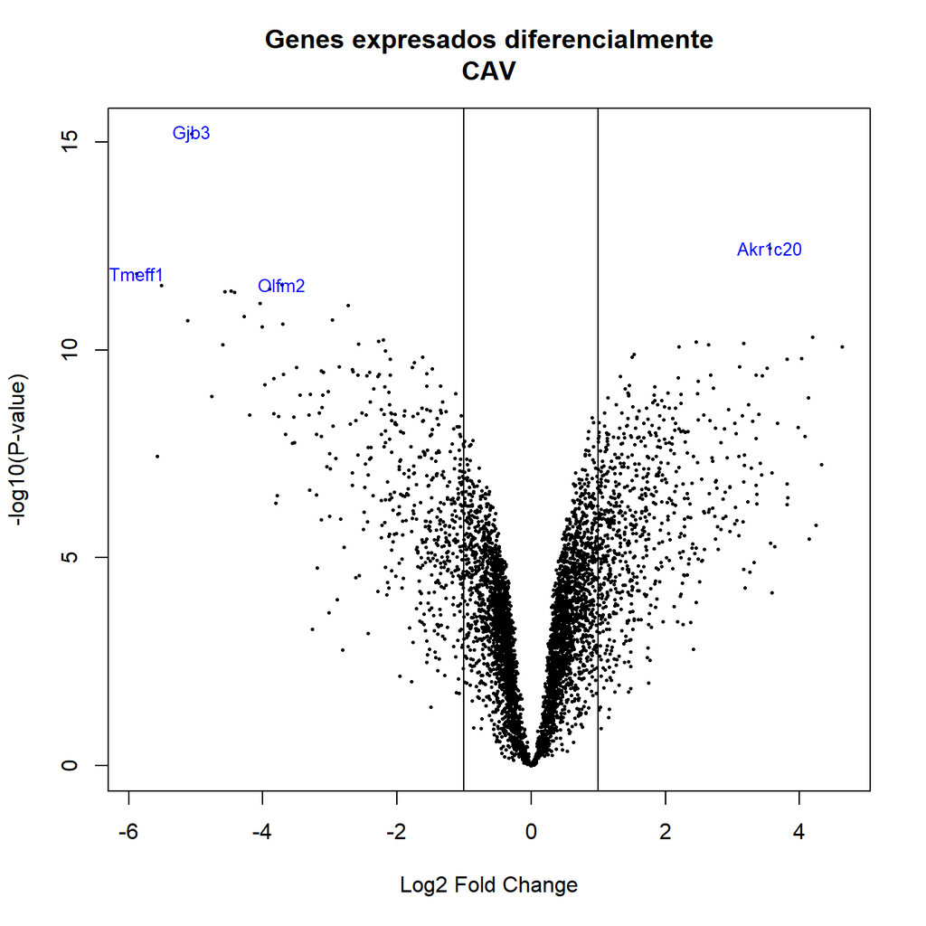

Figura 11.Volcano plot para la comparación entre hepatocitos cav incubados con TGFbeta1 y sin TGFbeta1

En el volcano plot mostrado enla figura 11 representa la comparación de los hepatocitos incubados con TGFbeta1 y sin TGFbeta 1 se observan genes downregulados(parte izquierda del volcanoplot), en los que destaca Tmeff1 y Olfm2. Como genes upregulados tenemos Akr1c20.

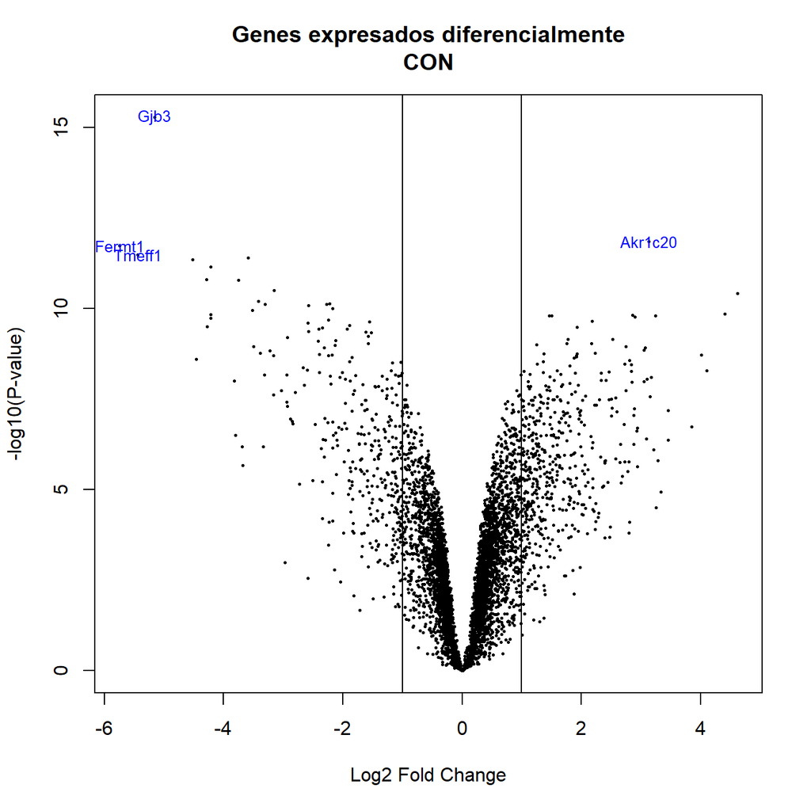

Figura 12.Volcano plot para la comparación entre hepatocitos CON incubados con TGFbeta1 y sin TGFbeta1

En la figura 12, el volcano plot para la comparación entre hepatocitos control incubados con el factor de crecimiento y sin, se destaca un gen downregulado más que en el caso anterior (Fermt1).

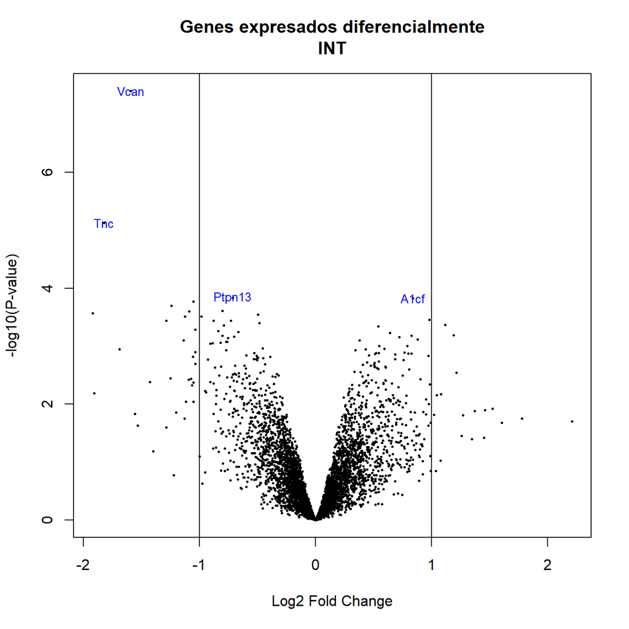

Figura 13.Volcano plot para la comparación entre hepatocitos CAV Y CON.

En la figura 13, el volcano plot donde se comparan los dos grupos hay dos genes a destacar que estan downregulados: “Voan” y “Tnc”.

## 3.17. Comparaciones múltiples

Cuando realizamos varias comparaciones a la vez puede resultar importante ver qué genes cambian simultánemente en más de una comparación.Si el número de comparaciones es alto, tmabién puede ser necesario realizar un ajuste de p-valores entre las comparaciones, distinto del realizado entre genes. Las funciones decidetests y VennDiagram del paquete limma permiten realizar éstas comparaciones.

```
        CAV  CON  INT
Down    462  330    2
NotSig 3939 4252 5073
Up      674  493    0
```

Diagrama de Venn

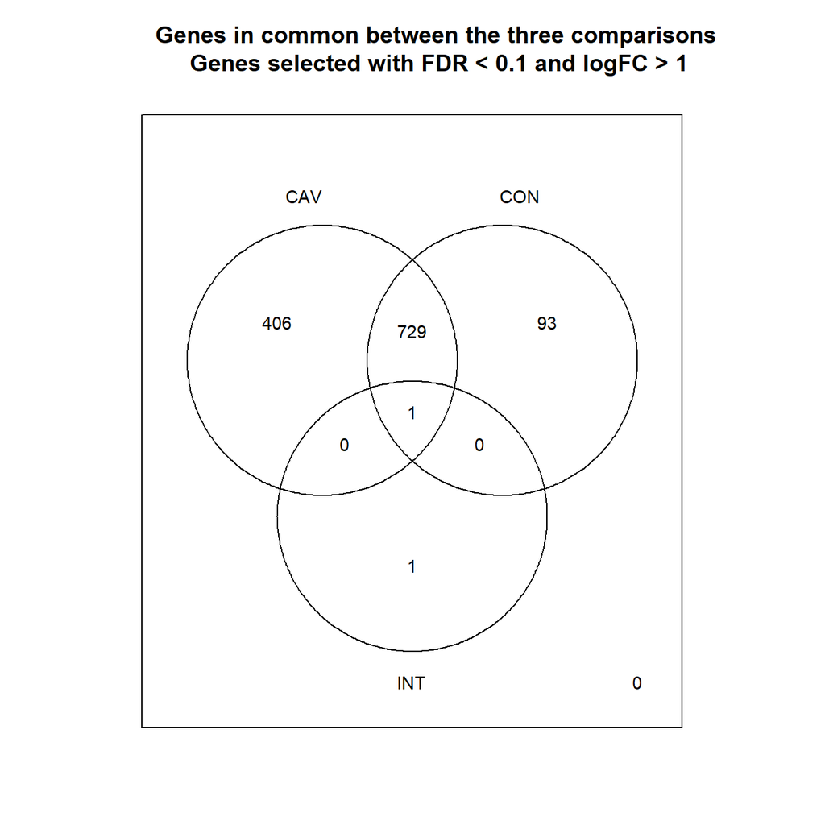

Figura 14.Diagrama de Venn donde se muestran los genes en comun entre las tres comparaciones

```r
> vennDiagram (res.selected[,1:3], cex=0.9)
> title("Genes in common between the three comparisons\n Genes selected with FDR < 0.1 and logFC > 1")
```

## 3.18. Heatmaps

Los genes que se han seleccionado como diferenciales expresados se pueden visualizar mediante un mapa de calor. Estas gráficas utilizan paletas de colores para resaltar valores distintos –aquí expresiones positivas (up-regulated) o negativas (down-regulated) diferenciadas significativamente.

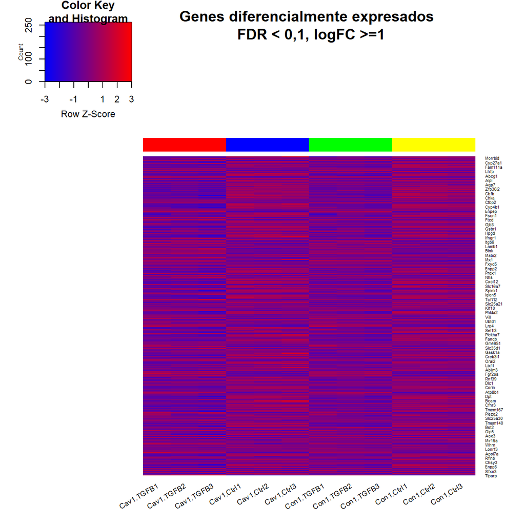

Figura 15.Heatmap de expresión sin agrupación

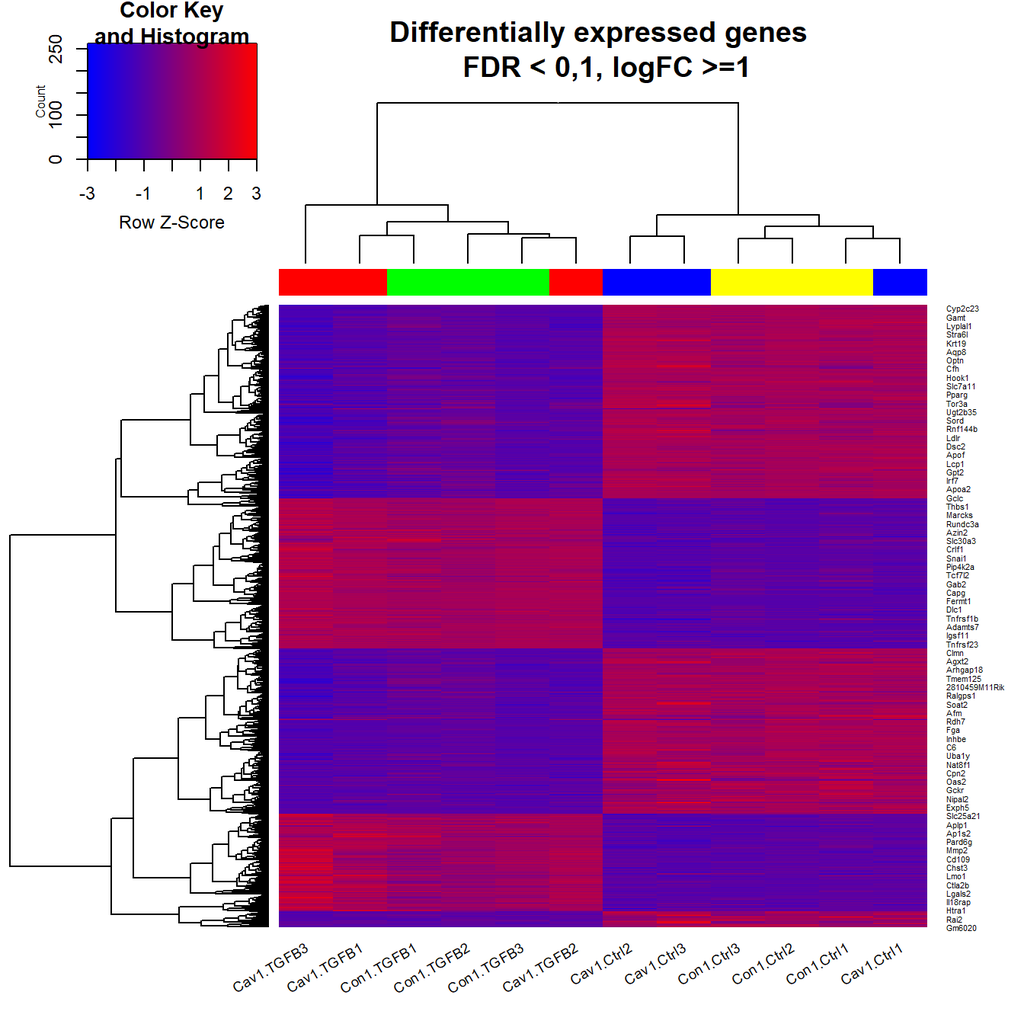

Figura 16.Heatmap de expresión agrupando genes (filas y muestras (columnas) por similaridad

## 3.19. Significación biológica de los resultados

Una vez obtenida una lista de genes que caracteriza la diferencia entre dos condiciones, debemos darle una interpretación. Determinaremos si, dada una lista de genes seleccionados con una expresión diferenciada las funciones, procesos biológicos o vías moleculares que los caracterizan aparecen en ésta lista con más frecuencia que el resto de genes analizados. Utilizaremos el análisis básico de enriquecimiento del paquete ReactomePA.

Los análisis de éste tipo necesitan un número mínimo de genes para ser fiables, preferiblemente unos pocos cientos que unas pocas docenas, por lo que es común realizar una selección menos restrictiva que con los pasos anteriores. Por ejemplo, una opcción es incluir todos los genes con un límite FDR no estricto, como FDR<0.15:

```
 CAV  CON  INT
4527 4351   90
```

El análisis también requiere que se analicen los identificadores para todos los genes disponibles:

```r
> mapped_genes2GO <- mappedkeys(org.Mm.egGO)
> mapped_genes2KEGG <- mappedkeys(org.Mm.egPATH)
> mapped_genes <- union(mapped_genes2GO , mapped_genes2KEGG)
```

```
##################################
Comparison:  CAV
                         ID                               Description GeneRatio
R-MMU-71291     R-MMU-71291 Metabolism of amino acids and derivatives  106/2241
R-MMU-8957322 R-MMU-8957322                    Metabolism of steroids   61/2241
R-MMU-191273   R-MMU-191273                  Cholesterol biosynthesis   19/2241
R-MMU-156580   R-MMU-156580       Phase II - Conjugation of compounds   44/2241
R-MMU-211859   R-MMU-211859                     Biological oxidations   83/2241
R-MMU-8978868 R-MMU-8978868                     Fatty acid metabolism   72/2241
               BgRatio       pvalue     p.adjust       qvalue
R-MMU-71291   249/8772 2.206230e-09 2.298892e-06 2.113337e-06
R-MMU-8957322 125/8772 1.546477e-08 8.057147e-06 7.406813e-06
R-MMU-191273   25/8772 1.759388e-07 6.110940e-05 5.617694e-05
R-MMU-156580   88/8772 6.573966e-07 1.406834e-04 1.293281e-04
R-MMU-211859  202/8772 7.521792e-07 1.406834e-04 1.293281e-04
R-MMU-8978868 169/8772 8.100769e-07 1.406834e-04 1.293281e-04
                                                                                                                                                                                                                                                                                                            …
R-MMU-71291   Gamt/Ftcd/Psat1/Glud1/Tat/Agxt2/Ethe1/Mat1a/Gstz1/Agmat/Slc6…
R-MMU-8957322                                                                                                                                                                                                 Akr1c20/Hsd11b2/Akr1c14/Abcc3/Slc10a2/Akr1c19/Vdr/Cyp7b1/Baa…
R-MMU-191273                                                                                                                                                                                                                                                                                                …
R-MMU-156580                                                                                                                                                                                                                                                                                                …
R-MMU-211859                                                                       Gclc/Ugt2b35/Gss/Gsto1/Fmo1/Ugt2b34/Gstm7/Gsta3/Mgst3/Glyat/…
R-MMU-8978868                                                                                                                                               Ptgs2/Acsbg1/Pla2g4a/Mid1ip1/Pccb/Slc27a2/Ptgs1/Dbi/Phyh/Acsl1/Acot2/Akr1c6/Cyp4f14/Acot12/Elovl6/Pon1/Thrsp/Scd2/Gpx4/Scp2/Acadm/Acaa2/Fads1/Ac…
              Count
R-MMU-71291     106
R-MMU-8957322    61
R-MMU-191273     19
R-MMU-156580     44
R-MMU-211859     83
R-MMU-8978868    72
```

```
##################################
Comparison:  CON
                         ID                               Description GeneRatio
R-MMU-8957322 R-MMU-8957322                    Metabolism of steroids   61/2175
R-MMU-71291     R-MMU-71291 Metabolism of amino acids and derivatives  100/2175
R-MMU-8978868 R-MMU-8978868                     Fatty acid metabolism   72/2175
R-MMU-156580   R-MMU-156580       Phase II - Conjugation of compounds   43/2175
R-MMU-191273   R-MMU-191273                  Cholesterol biosynthesis   18/2175
R-MMU-211859   R-MMU-211859                     Biological oxidations   81/2175
               BgRatio       pvalue     p.adjust       qvalue
R-MMU-8957322 125/8772 4.555055e-09 4.723592e-06 4.305726e-06
R-MMU-71291   249/8772 4.363978e-08 2.262722e-05 2.062554e-05
R-MMU-8978868 169/8772 2.354947e-07 8.140268e-05 7.420150e-05
R-MMU-156580   88/8772 8.177640e-07 1.557632e-04 1.419838e-04
R-MMU-191273   25/8772 8.939781e-07 1.557632e-04 1.419838e-04
R-MMU-211859  202/8772 9.012338e-07 1.557632e-04 1.419838e-04
                                                                                                                                                                                                                                                                                                            …
R-MMU-8957322                                                                                                                                                                  Akr1c20/Hsd11b2/Akr1c14/Akr1c19/Slc10a2/Vdr/Abcc3/Akr1c18/Cy…
R-MMU-71291   Psat1/Gamt/Tat/Ftcd/Serinc5/Slc6a8/Ethe1/Shmt1/Glud1/Mat1a/A…
R-MMU-8978868                                                                                                                 Mid1ip1/Acsbg1/Cyp4f14/Ptgs2/Pccb/Acot2/Elovl6/Scd2/Slc27a2/…-Ke6/Acot1/Acot6/Them5/Prkaa2/Cyp2j6/Ephx2/Acadl/Alox5/Mecr/Morc2a/Cyp4b1/Scd1/Cyp4a31/Pon1/Cyp4a12a/Cyp4a12b/Eci…
R-MMU-156580                                                                                                                                                                                                                                                                                                …
R-MMU-191273                                                                                                                                                                                                                                                                                                …
R-MMU-211859                                                Gsto1/Ugt2b35/Fmo1/Gstm7/Gss/Gclc/Ugt2b34/Cyp4f14/Fmo2/Glyat…
              Count
R-MMU-8957322    61
R-MMU-71291     100
R-MMU-8978868    72
R-MMU-156580     43
R-MMU-191273     18
R-MMU-211859     81
```

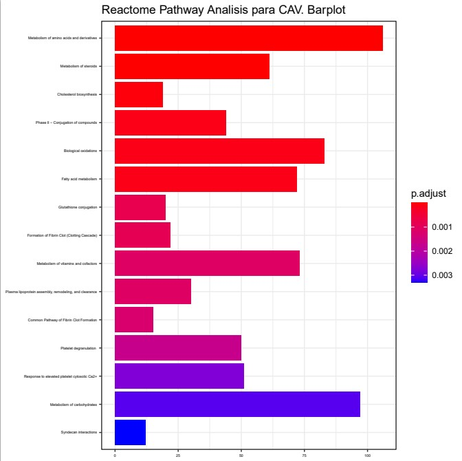

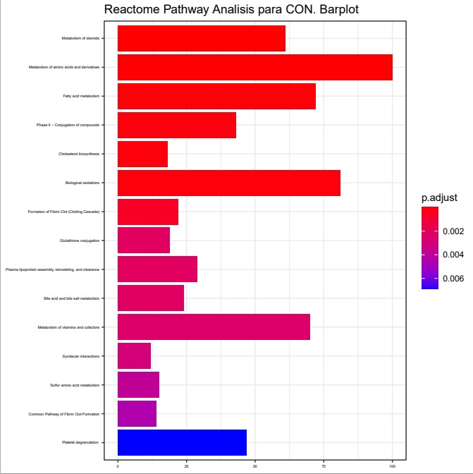

Observamos que hay elementos comunes entre ambas comparaciones, como por ejemplo la implicación en el metabolismo de los aminoácidos y sus derivados.

Las figuras 19 y 20 nos muestran los CNEplot de ambos grupos:

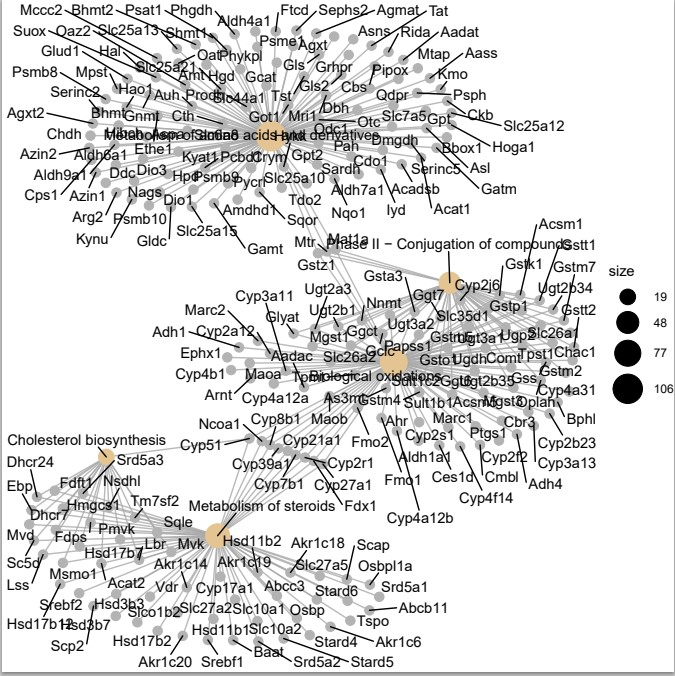

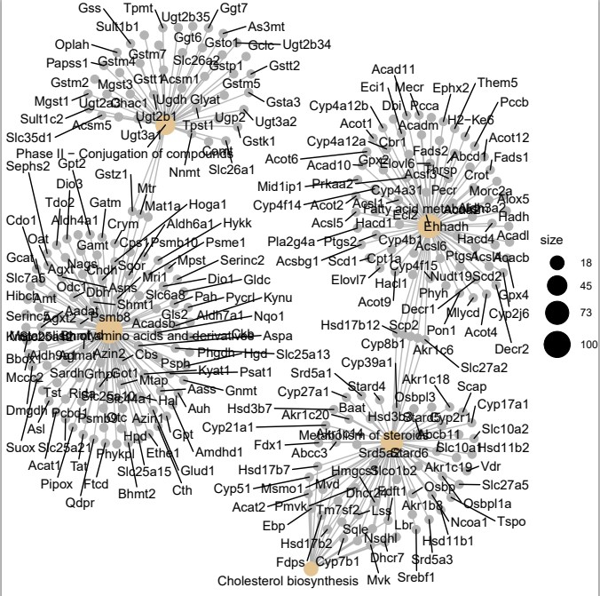

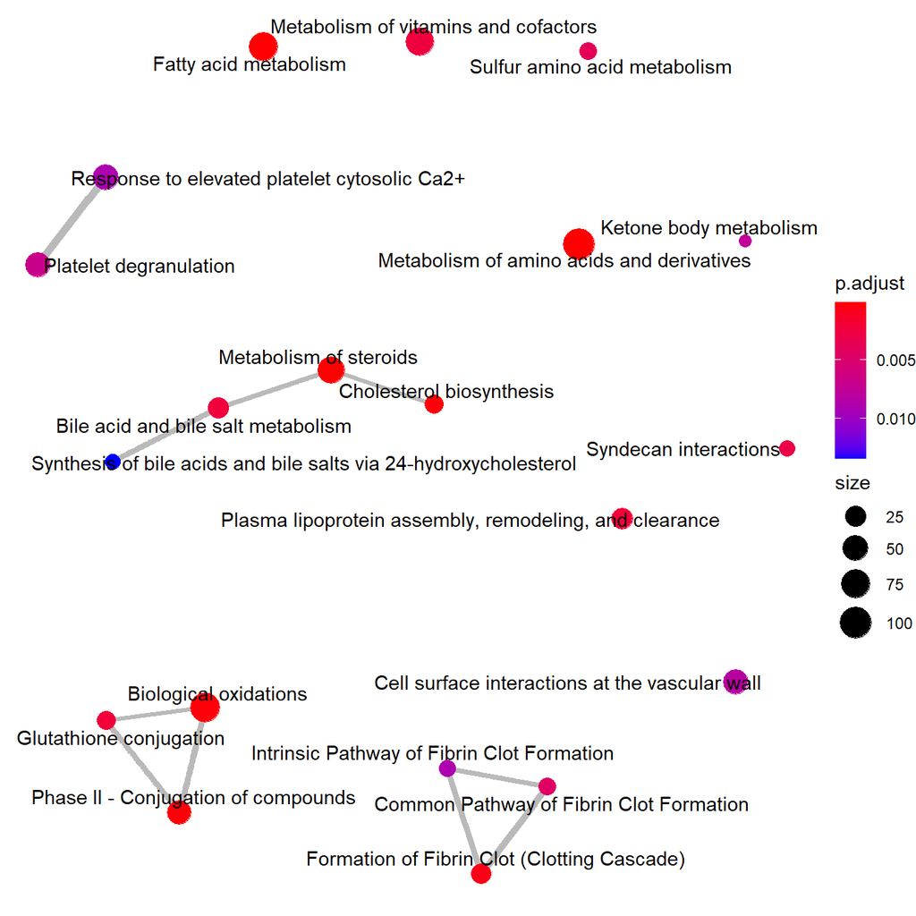

En las dos tablas siguientes se muestran las vias más relevantes para las comparaciones CAV y CON, mostramos las primeras 5 lineas:

Primeras filas y columnas para la comparacion CAV

|  | Description | GeneRatio | BgRatio | pvalue | p.adjust |
| --- | --- | --- | --- | --- | --- |
| R-MMU-71291 | Metabolism of amino acids and derivatives | 106/2241 | 249/8772 | 2.20623045495775e-09 | 2.29889213406597e-06 |
| R-MMU-8957322 | Metabolism of steroids | 61/2241 | 125/8772 | 1.54647735227951e-08 | 8.05714700537623e-06 |
| R-MMU-191273 | Cholesterol biosynthesis | 19/2241 | 25/8772 | 1.75938777029171e-07 | 6.11094018881319e-05 |
| R-MMU-156580 | Phase II - Conjugation of compounds | 44/2241 | 88/8772 | 6.57396625522371e-07 | 0.000140683363370677 |
| R-MMU-211859 | Biological oxidations | 83/2241 | 202/8772 | 7.52179247770328e-07 | 0.000140683363370677 |

Primeras filas y columnas para la comparacion CON

|  | Description | GeneRatio | BgRatio | pvalue | p.adjust |
| --- | --- | --- | --- | --- | --- |
| R-MMU-8957322 | Metabolism of steroids | 61/2175 | 125/8772 | 4.55505489760112e-09 | 4.72359192881236e-06 |
| R-MMU-71291 | Metabolism of amino acids and derivatives | 100/2175 | 249/8772 | 4.36397779980559e-08 | 2.2627224891992e-05 |
| R-MMU-8978868 | Fatty acid metabolism | 72/2175 | 169/8772 | 2.3549474272351e-07 | 8.140268273476e-05 |
| R-MMU-156580 | Phase II - Conjugation of compounds | 43/2175 | 88/8772 | 8.17764037688801e-07 | 0.000155763233681676 |
| R-MMU-191273 | Cholesterol biosynthesis | 18/2175 | 25/8772 | 8.93978148867076e-07 | 0.000155763233681676 |

# 4. Código R

Debido a la extensión del código no se ha mostrado en su totalidad en el archivo en pdf, está recopilado íntegramente como apéndice en el archivo rcode.txt en la carpeta results y además está disponible en su totalidad en el archivo cartoixa_david_ADO_PEC1.rmd.

# 5. Referencias

Ricardo Gonzalo, Sanchez-Pla A. Statistical analysis of microarray data 2019. https://github.com/ASPteaching/Omics_Data_Analysis-Case_Study_1-Microarrays

Mei Han, Zeribe Chike Nwosu, Weronika Pooronska, Matthias Philip Ebert, Steven Dooley, Christoph Meyer. Caveolin-1 Impacts on TGFBetha Regulation of Metabolic Gene Signatures in Hepatocytes. Front Physiol. 2020 Jan 21;10:1606.doi:10.3389/fphys.2019.01606.eCollection 2019.